# Extensive Data Cleaning Example

## Things Get Messy Below - Just know I am working towards having counts of total delayed flights, to then divide them by total flights by airport

```python
late_arrivals.head(15)
```

|  | AIRLINE | FLIGHT_NUMBER | ORIGIN_AIRPORT | DESTINATION_AIRPORT | SCHEDULED_DEPARTURE | DEPARTURE_TIME | DEPARTURE_DELAY | WHEELS_OFF | SCHEDULED_TIME | DISTANCE | SCHEDULED_ARRIVAL | ARRIVAL_TIME | CANCELLED | NEW_ARRIVAL_DELAY_FULL |
| --- | --- | --- | --- | --- | --- | --- | --- | --- | --- | --- | --- | --- | --- | --- |
| 2 | US | 840 | SFO | CLT | 20 | 18.0 | -2.0 | 34.0 | 286.0 | 2296 | 806 | 811.0 | 0 | 5.0 |
| 5 | DL | 806 | SFO | MSP | 25 | 20.0 | -5.0 | 38.0 | 217.0 | 1589 | 602 | 610.0 | 0 | 8.0 |
| 14 | DL | 2440 | SEA | MSP | 40 | 39.0 | -1.0 | 107.0 | 189.0 | 1399 | 549 | 557.0 | 0 | 8.0 |
| 20 | NK | 520 | LAS | MCI | 55 | 120.0 | 25.0 | 131.0 | 162.0 | 1139 | 537 | 543.0 | 0 | 6.0 |
| 21 | AA | 371 | SEA | MIA | 100 | 52.0 | -8.0 | 122.0 | 338.0 | 2724 | 938 | 939.0 | 0 | 1.0 |
| 27 | NK | 597 | MSP | FLL | 115 | 127.0 | 12.0 | 141.0 | 207.0 | 1487 | 542 | 607.0 | 0 | 65.0 |
| 29 | AA | 2392 | DEN | MIA | 120 | 141.0 | 21.0 | 153.0 | 227.0 | 1709 | 707 | 709.0 | 0 | 2.0 |
| 30 | NK | 168 | PHX | ORD | 125 | 237.0 | 72.0 | 246.0 | 204.0 | 1440 | 549 | 632.0 | 0 | 83.0 |
| 33 | DL | 95 | SLC | ATL | 140 | 134.0 | -6.0 | 217.0 | 215.0 | 1590 | 715 | 725.0 | 0 | 10.0 |
| 35 | HA | 17 | LAS | HNL | 145 | 145.0 | 0.0 | 201.0 | 370.0 | 2762 | 555 | 610.0 | 0 | 55.0 |
| 39 | B6 | 304 | SJU | JFK | 155 | 153.0 | -2.0 | 205.0 | 235.0 | 1598 | 450 | 501.0 | 0 | 51.0 |
| 41 | NK | 972 | PHX | DFW | 159 | 158.0 | -1.0 | 209.0 | 123.0 | 868 | 502 | 503.0 | 0 | 1.0 |
| 45 | B6 | 1990 | SJU | EWR | 206 | 152.0 | -14.0 | 211.0 | 246.0 | 1608 | 512 | 516.0 | 0 | 4.0 |
| 49 | UA | 1162 | BQN | EWR | 259 | 258.0 | -1.0 | 312.0 | 240.0 | 1585 | 559 | 605.0 | 0 | 46.0 |
| 50 | B6 | 1030 | BQN | MCO | 307 | 304.0 | -3.0 | 329.0 | 173.0 | 1129 | 500 | 520.0 | 0 | 20.0 |

```python
early_arrival.head(5)
```

|  | AIRLINE | FLIGHT_NUMBER | ORIGIN_AIRPORT | DESTINATION_AIRPORT | SCHEDULED_DEPARTURE | DEPARTURE_TIME | DEPARTURE_DELAY | WHEELS_OFF | SCHEDULED_TIME | DISTANCE | SCHEDULED_ARRIVAL | ARRIVAL_TIME | CANCELLED | NEW_ARRIVAL_DELAY_FULL |
| --- | --- | --- | --- | --- | --- | --- | --- | --- | --- | --- | --- | --- | --- | --- |
| 0 | AS | 98 | ANC | SEA | 5 | 2354.0 | -11.0 | 15.0 | 205.0 | 1448 | 430 | 408.0 | 0 | -22.0 |
| 1 | AA | 2336 | LAX | PBI | 10 | 2.0 | -8.0 | 14.0 | 280.0 | 2330 | 750 | 741.0 | 0 | -9.0 |
| 3 | AA | 258 | LAX | MIA | 20 | 15.0 | -5.0 | 30.0 | 285.0 | 2342 | 805 | 756.0 | 0 | -49.0 |
| 4 | AS | 135 | SEA | ANC | 25 | 24.0 | -1.0 | 35.0 | 235.0 | 1448 | 320 | 259.0 | 0 | -61.0 |
| 6 | NK | 612 | LAS | MSP | 25 | 19.0 | -6.0 | 30.0 | 181.0 | 1299 | 526 | 509.0 | 0 | -17.0 |

```python
arriving_later = late_arrivals.groupby('ORIGIN_AIRPORT')[['ORIGIN_AIRPORT','NEW_ARRIVAL_DELAY_FULL']].count()
```

```python
print(arriving_later)
```

```
                ORIGIN_AIRPORT  NEW_ARRIVAL_DELAY_FULL
ORIGIN_AIRPORT
ABE                        831                     831
ABI                        687                     687
ABQ                       6954                    6954
ABR                        246                     246
ABY                        310                     310
...                        ...                     ...
WRG                        236                     236
WYS                         58                      58
XNA                       3732                    3732
YAK                        159                     159
YUM                        626                     626

[322 rows x 2 columns]
```

```python
arriving_later.sort_values('NEW_ARRIVAL_DELAY_FULL')
```

| ORIGIN_AIRPORT | ORIGIN_AIRPORT | NEW_ARRIVAL_DELAY_FULL |
| --- | --- | --- |
| CNY | 8 | 8 |
| ITH | 14 | 14 |
| DLG | 17 | 17 |
| HYA | 21 | 21 |
| VEL | 23 | 23 |
| ... | ... | ... |
| LAX | 77263 | 77263 |
| DEN | 77319 | 77319 |
| DFW | 90100 | 90100 |
| ORD | 109512 | 109512 |
| ATL | 111753 | 111753 |

322 rows × 2 columns

```python
type(arriving_later)
```

```
pandas.core.frame.DataFrame
```

```python
arriving_early = early_arrival.groupby('ORIGIN_AIRPORT')[['ORIGIN_AIRPORT','NEW_ARRIVAL_DELAY_FULL']].count()
```

```python
print(arriving_early)
```

```
                ORIGIN_AIRPORT  NEW_ARRIVAL_DELAY_FULL
ORIGIN_AIRPORT
ABE                       1359                    1359
ABI                       1504                    1504
ABQ                      11561                   11561
ABR                        390                     390
ABY                        538                     538
...                        ...                     ...
WRG                        398                     398
WYS                        142                     142
XNA                       5055                    5055
YAK                        477                     477
YUM                       1174                    1174

[322 rows x 2 columns]
```

```python
arriving_early.head()
```

| ORIGIN_AIRPORT | ORIGIN_AIRPORT | NEW_ARRIVAL_DELAY_FULL |
| --- | --- | --- |
| ABE | 1359 | 1359 |
| ABI | 1504 | 1504 |
| ABQ | 11561 | 11561 |
| ABR | 390 | 390 |
| ABY | 538 | 538 |

```python
arriving_later.head()
```

| ORIGIN_AIRPORT | ORIGIN_AIRPORT | NEW_ARRIVAL_DELAY_FULL |
| --- | --- | --- |
| ABE | 831 | 831 |
| ABI | 687 | 687 |
| ABQ | 6954 | 6954 |
| ABR | 246 | 246 |
| ABY | 310 | 310 |

```python
#type(late_arrival)
```

```python
arriving_later.head()
```

| ORIGIN_AIRPORT | ORIGIN_AIRPORT | NEW_ARRIVAL_DELAY_FULL |
| --- | --- | --- |
| ABE | 831 | 831 |
| ABI | 687 | 687 |
| ABQ | 6954 | 6954 |
| ABR | 246 | 246 |
| ABY | 310 | 310 |

```python
print(num_flights_airport)
```

```
ORIGIN_AIRPORT
ABE     2234
ABI     2232
ABQ    18967
ABR      663
ABY      867
       ...
WRG      649
WYS      208
XNA     8986
YAK      650
YUM     1854
Length: 322, dtype: int64
```

```python
late_counts = arriving_later['NEW_ARRIVAL_DELAY_FULL']
```

```python
print(late_counts)
```

```
ORIGIN_AIRPORT
ABE     831
ABI     687
ABQ    6954
ABR     246
ABY     310
       ...
WRG     236
WYS      58
XNA    3732
YAK     159
YUM     626
Name: NEW_ARRIVAL_DELAY_FULL, Length: 322, dtype: int64
```

```python
type(late_counts)
```

```
pandas.core.series.Series
```

```python
late_counts.sort_values()
```

```
ORIGIN_AIRPORT
CNY         8
ITH        14
DLG        17
HYA        21
VEL        23
        ...
LAX     77263
DEN     77319
DFW     90100
ORD    109512
ATL    111753
Name: NEW_ARRIVAL_DELAY_FULL, Length: 322, dtype: int64
```

```python
type(num_flights_airport)
```

```
pandas.core.series.Series
```

```python
num_flights_airport.sort_values()
```

```
ORIGIN_AIRPORT
ITH        30
AKN        63
GST        76
DLG        77
STC        78
        ...
LAX    192399
DEN    193828
DFW    233177
ORD    277140
ATL    344165
Length: 322, dtype: int64
```

```python
#late_prob = num_flights_airport.apply(lambda late_counts: late_counts/num_flights_airport)
```

```python
#late_prob
```

```python
flights_df_copy['delay_yes_no'] = np.where(flights_df_copy['NEW_ARRIVAL_DELAY_FULL'] > 0, True, False)
```

```python
flights_df_copy.head()
```

|  | AIRLINE | FLIGHT_NUMBER | ORIGIN_AIRPORT | DESTINATION_AIRPORT | SCHEDULED_DEPARTURE | DEPARTURE_TIME | DEPARTURE_DELAY | WHEELS_OFF | SCHEDULED_TIME | DISTANCE | SCHEDULED_ARRIVAL | ARRIVAL_TIME | CANCELLED | NEW_ARRIVAL_DELAY_FULL | delay_yes_no |
| --- | --- | --- | --- | --- | --- | --- | --- | --- | --- | --- | --- | --- | --- | --- | --- |
| 0 | AS | 98 | ANC | SEA | 5 | 2354.0 | -11.0 | 15.0 | 205.0 | 1448 | 430 | 408.0 | 0 | -22.0 | False |
| 1 | AA | 2336 | LAX | PBI | 10 | 2.0 | -8.0 | 14.0 | 280.0 | 2330 | 750 | 741.0 | 0 | -9.0 | False |
| 2 | US | 840 | SFO | CLT | 20 | 18.0 | -2.0 | 34.0 | 286.0 | 2296 | 806 | 811.0 | 0 | 5.0 | True |
| 3 | AA | 258 | LAX | MIA | 20 | 15.0 | -5.0 | 30.0 | 285.0 | 2342 | 805 | 756.0 | 0 | -49.0 | False |
| 4 | AS | 135 | SEA | ANC | 25 | 24.0 | -1.0 | 35.0 | 235.0 | 1448 | 320 | 259.0 | 0 | -61.0 | False |

```python
#print(flights_df_copy)
```

```python
#print(pd.DataFrame({'Percentage' : flights_df_copy.groupby(('ORIGIN_AIRPORT')).size() /len(flights_df_copy)}))
```

```python
#flights_df_copy['Proportion'] = flights_df_copy['delay_yes_no']/flights_df_copy['delay_yes_no'].sum()
```

```python
#flights_df_copy['Proportion']
```

```python
#flights_df_copy.drop(['Proportion'], axis=1)
```

```python
#def compute_proportion(x):
   # pct = float(x/flights_df_copy[''])

#f = lambda x: 100 * x / float(x.sum())
```

```python
#flights_df_copy['perc_late'] = (flights_df_copy.groupby(['ORIGIN_AIRPORT'])['NEW_ARRIVAL_DELAY_FULL'].transform(f))
```

```python
flights_df_copy.head()
```

|  | AIRLINE | FLIGHT_NUMBER | ORIGIN_AIRPORT | DESTINATION_AIRPORT | SCHEDULED_DEPARTURE | DEPARTURE_TIME | DEPARTURE_DELAY | WHEELS_OFF | SCHEDULED_TIME | DISTANCE | SCHEDULED_ARRIVAL | ARRIVAL_TIME | CANCELLED | NEW_ARRIVAL_DELAY_FULL | delay_yes_no |
| --- | --- | --- | --- | --- | --- | --- | --- | --- | --- | --- | --- | --- | --- | --- | --- |
| 0 | AS | 98 | ANC | SEA | 5 | 2354.0 | -11.0 | 15.0 | 205.0 | 1448 | 430 | 408.0 | 0 | -22.0 | False |
| 1 | AA | 2336 | LAX | PBI | 10 | 2.0 | -8.0 | 14.0 | 280.0 | 2330 | 750 | 741.0 | 0 | -9.0 | False |
| 2 | US | 840 | SFO | CLT | 20 | 18.0 | -2.0 | 34.0 | 286.0 | 2296 | 806 | 811.0 | 0 | 5.0 | True |
| 3 | AA | 258 | LAX | MIA | 20 | 15.0 | -5.0 | 30.0 | 285.0 | 2342 | 805 | 756.0 | 0 | -49.0 | False |
| 4 | AS | 135 | SEA | ANC | 25 | 24.0 | -1.0 | 35.0 | 235.0 | 1448 | 320 | 259.0 | 0 | -61.0 | False |

```python
#flights_df_copy.reset_index().sort(['ORIGIN_AIRPORT'])
```

```python
flights_df_copy['transform_perc'] = flights_df_copy['delay_yes_no'] / flights_df_copy.groupby('ORIGIN_AIRPORT')['delay_yes_no'].transform(sum)
```

```python
print(flights_df_copy.groupby('ORIGIN_AIRPORT')['transform_perc'].sum())
```

```
ORIGIN_AIRPORT
ABE    1.0
ABI    1.0
ABQ    1.0
ABR    1.0
ABY    1.0
      ...
WRG    1.0
WYS    1.0
XNA    1.0
YAK    1.0
YUM    1.0
Name: transform_perc, Length: 322, dtype: float64
```

```python
print(flights_df_copy.groupby('ORIGIN_AIRPORT')['transform_perc'].count())
```

```
ORIGIN_AIRPORT
ABE     2234
ABI     2232
ABQ    18967
ABR      663
ABY      867
       ...
WRG      649
WYS      208
XNA     8986
YAK      650
YUM     1854
Name: transform_perc, Length: 322, dtype: int64
```

```python
flights_df_copy.groupby(['ORIGIN_AIRPORT', 'delay_yes_no']).size().unstack()
```

| delay_yes_no ORIGIN_AIRPORT | False | True |
| --- | --- | --- |
| ABE | 1403 | 831 |
| ABI | 1545 | 687 |
| ABQ | 12013 | 6954 |
| ABR | 417 | 246 |
| ABY | 557 | 310 |
| ... | ... | ... |
| WRG | 413 | 236 |
| WYS | 150 | 58 |
| XNA | 5254 | 3732 |
| YAK | 491 | 159 |
| YUM | 1228 | 626 |

322 rows × 2 columns

```python
actual_counts = flights_df_copy.groupby(['ORIGIN_AIRPORT', 'delay_yes_no']).size().unstack()
```

```python
actual_counts
```

| delay_yes_no ORIGIN_AIRPORT | False | True |
| --- | --- | --- |
| ABE | 1403 | 831 |
| ABI | 1545 | 687 |
| ABQ | 12013 | 6954 |
| ABR | 417 | 246 |
| ABY | 557 | 310 |
| ... | ... | ... |
| WRG | 413 | 236 |
| WYS | 150 | 58 |
| XNA | 5254 | 3732 |
| YAK | 491 | 159 |
| YUM | 1228 | 626 |

322 rows × 2 columns

```python
type(actual_counts)
```

```
pandas.core.frame.DataFrame
```

```python
actual_counts.max()
```

```
delay_yes_no
False    232412
True     111753
dtype: int64
```

```python
actual_counts.describe()
```

| delay_yes_no | False | True |
| --- | --- | --- |
| count | 322.000000 | 322.000000 |
| mean | 10377.338509 | 5905.183230 |
| std | 25134.851057 | 14775.490175 |
| min | 16.000000 | 8.000000 |
| 25% | 557.250000 | 286.500000 |
| 50% | 1683.500000 | 863.500000 |
| 75% | 5778.000000 | 3051.000000 |
| max | 232412.000000 | 111753.000000 |

```python
#actual_counts[1]
```

```python
#actual_counts.head()
```

```python
#actual_counts.loc['10135']
```

```python
actual_counts[1]
```

```
ORIGIN_AIRPORT
ABE     831
ABI     687
ABQ    6954
ABR     246
ABY     310
       ...
WRG     236
WYS      58
XNA    3732
YAK     159
YUM     626
Name: True, Length: 322, dtype: int64
```

```python
actual_counts['total'] = actual_counts[0] + actual_counts[1]
```

```python
actual_counts.head(10)
```

| delay_yes_no ORIGIN_AIRPORT | False | True | total |
| --- | --- | --- | --- |
| ABE | 1403 | 831 | 2234 |
| ABI | 1545 | 687 | 2232 |
| ABQ | 12013 | 6954 | 18967 |
| ABR | 417 | 246 | 663 |
| ABY | 557 | 310 | 867 |
| ACK | 324 | 162 | 486 |
| ACT | 1075 | 464 | 1539 |
| ACV | 820 | 449 | 1269 |
| ACY | 2103 | 1429 | 3532 |
| ADK | 33 | 56 | 89 |

```python
actual_counts['total']
```

```
ORIGIN_AIRPORT
ABE     2234
ABI     2232
ABQ    18967
ABR      663
ABY      867
       ...
WRG      649
WYS      208
XNA     8986
YAK      650
YUM     1854
Name: total, Length: 322, dtype: int64
```

```python
actual_counts['false'] = actual_counts[0]
```

```python
actual_counts['true'] = actual_counts[1]
```

```python
actual_counts.head()
```

| delay_yes_no ORIGIN_AIRPORT | False | True | total | false | true |
| --- | --- | --- | --- | --- | --- |
| ABE | 1403 | 831 | 2234 | 1403 | 831 |
| ABI | 1545 | 687 | 2232 | 1545 | 687 |
| ABQ | 12013 | 6954 | 18967 | 12013 | 6954 |
| ABR | 417 | 246 | 663 | 417 | 246 |
| ABY | 557 | 310 | 867 | 557 | 310 |

```python
actual_counts['false'].max()
```

```
232412
```

```python
actual_counts['prop_delayed'] = actual_counts['true'] / actual_counts['total']
```

```python
actual_counts.head()
```

| delay_yes_no ORIGIN_AIRPORT | False | True | total | false | true | prop_delayed |
| --- | --- | --- | --- | --- | --- | --- |
| ABE | 1403 | 831 | 2234 | 1403 | 831 | 0.371979 |
| ABI | 1545 | 687 | 2232 | 1545 | 687 | 0.307796 |
| ABQ | 12013 | 6954 | 18967 | 12013 | 6954 | 0.366637 |
| ABR | 417 | 246 | 663 | 417 | 246 | 0.371041 |
| ABY | 557 | 310 | 867 | 557 | 310 | 0.357555 |

```python
actual_counts['prop_delayed'].max()
```

```
0.6710526315789473
```

```python
actual_counts['prop_delayed'].idxmax()
```

```
'GST'
```

```python
actual_counts['prop_delayed'].min()
```

```
0.03902439024390244
```

```python
actual_counts['prop_delayed'].idxmin()
```

```
'CNY'
```

```python
#actual_counts.loc['10268']
```

```python
actual_counts.sort_values('prop_delayed')
```

| delay_yes_no ORIGIN_AIRPORT | False | True | total | false | true | prop_delayed |
| --- | --- | --- | --- | --- | --- | --- |
| CNY | 197 | 8 | 205 | 197 | 8 | 0.039024 |
| VEL | 177 | 23 | 200 | 177 | 23 | 0.115000 |
| BTM | 548 | 99 | 647 | 548 | 99 | 0.153014 |
| LWS | 491 | 97 | 588 | 491 | 97 | 0.164966 |
| DIK | 727 | 194 | 921 | 727 | 194 | 0.210641 |
| ... | ... | ... | ... | ... | ... | ... |
| STC | 39 | 39 | 78 | 39 | 39 | 0.500000 |
| AKN | 31 | 32 | 63 | 31 | 32 | 0.507937 |
| ADK | 33 | 56 | 89 | 33 | 56 | 0.629213 |
| PPG | 39 | 68 | 107 | 39 | 68 | 0.635514 |
| GST | 25 | 51 | 76 | 25 | 51 | 0.671053 |

322 rows × 6 columns

```python
type(actual_counts)
```

```
pandas.core.frame.DataFrame
```

### We have finally got here after a great deal of help from our Professor, and are now seeing that our Regional Airports are messing up our min/max analysis here with very low sample sizes. Lets clean them out of this to see our real min and max delayed airports with enough sample size to be releveant.

```python
#flights_df_copy[flights_df_copy['ORIGIN_AIRPORT'].str.contains('1')==False]
```

### For clarity I'm going to comment out the above line and run it much higher up in our cleaning stage, but know it was originally down here. We will then have to run our actual_counts again.

# Highest Proportion delayed is GST, Lowest is CNY, lets get to Analysis!!

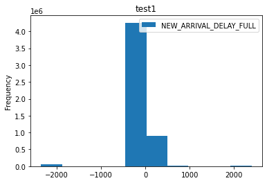

```python
flights_df_copy.plot(x='ORIGIN_AIRPORT', y='NEW_ARRIVAL_DELAY_FULL', kind='hist', title ='test1')
```

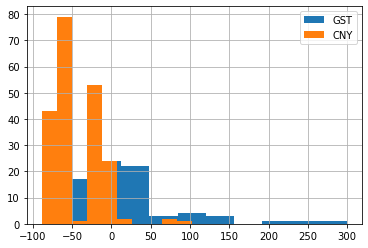

```python
flights_df_copy[flights_df_copy['ORIGIN_AIRPORT'] == 'GST']['NEW_ARRIVAL_DELAY_FULL'].hist()

flights_df_copy[flights_df_copy['ORIGIN_AIRPORT'] == 'CNY']['NEW_ARRIVAL_DELAY_FULL'].hist()

plt.legend(['GST','CNY'])
##GST is Gustavus Airport in Alaska, CNY is Canyonlands in Moab, Utah
plt.show()
```

```python
flights_df_copy[flights_df_copy['ORIGIN_AIRPORT'] == 'GST']['NEW_ARRIVAL_DELAY_FULL'].describe()
```

```
count     76.000000
mean      20.184211
std       66.060318
min      -59.000000
25%       -2.250000
50%       10.500000
75%       28.750000
max      299.000000
Name: NEW_ARRIVAL_DELAY_FULL, dtype: float64
```

```python
flights_df_copy[flights_df_copy['ORIGIN_AIRPORT'] == 'CNY']['NEW_ARRIVAL_DELAY_FULL'].describe()
```

```
count    205.000000
mean     -43.897561
std       30.808139
min      -88.000000
25%      -67.000000
50%      -62.000000
75%      -18.000000
max      103.000000
Name: NEW_ARRIVAL_DELAY_FULL, dtype: float64
```

Looking at mean and standard dev tell a similar story to what our graph says; the majority of flights from our CNY Canyonlands Airports are arriving earlier than scheduled, shown by a mean of -43. We also see much lower deviatoin, meaning we can pretty consistently say we will arrive early, when compared to our other extreme in the GST Alaskan Airport, which receives quite a bit of delays, and with some outliers of heavy delays, reflected in the much higher std compared to CMT.